# septum_lateral

[figure not shown]

## Overview

Welcome to the septum_lateral project! These experiments generated several interactive websites for you to browse and download.

In our previous work, www.nature.com/articles/s41386-022-01487-y, we demonstrated that expression of tropomyosin kinase receptor B (TrkB) in LS neurons is required for social novelty recognition. To better understand how TrkB signaling may control social behavior, we locally knocked down TrkB in the LS and used bulk RNA-sequencing to identify changes in gene expression between 4 mice with TrkB knockdown in the LS (cre) and 4 control mice with viral expression of GFP (GFP). Additionally, we generated molecular profiles for LS cell types using single nucleus RNA-sequencing (snRNA-seq) on N = 4 samples (generated from n=4 males, n=4 females, each sample contained pooled LS dissections of 2 mice of the same sex). Once these datasets were generated, our final goal was to intersect them to identify whether DEGs identified from the TrkB knockdown bulk RNA-seq data are enriched in the cell types identified using our snRNA-seq data.

For more detailed information about study design and experimental results, please refer to our manuscript www.biorxiv.org/content/10.1101/2023.06.29.547069v2. This work was performed by Keri Martinowich, Stephanie Cerceo Page, and Leonardo Collado-Torres teams at the Lieber Institute for Brain Development.

This project involves the GitHub repository github.com/LieberInstitute/septum_lateral

## Study Design

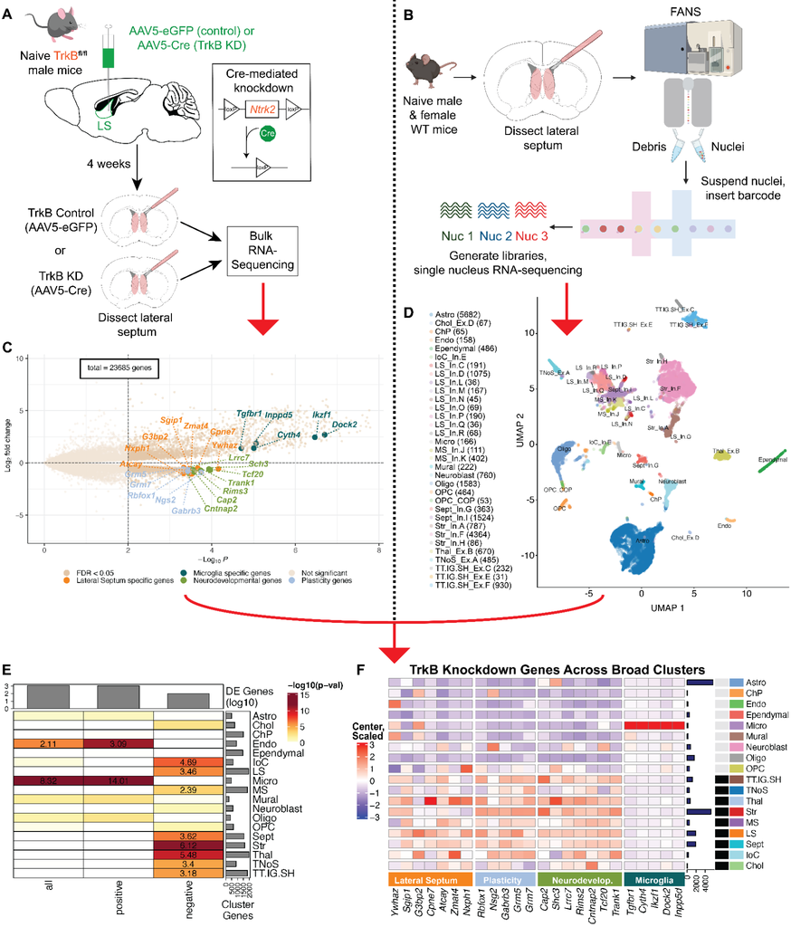

**Study design to identify molecular changes induced by TrkB knockdown in newly identified LS cell-types using snRNA-seq**. (**A**) Schematic of viral strategy using cre-mediated recombination to locally knockdown TrkB expression in the LS (n=4 TrkB KD, n=4 TrkB Control). (**B**) Schematic of experimental design for snRNA-seq of mouse LS tissue. Tissues from 2 mice of the same sex were pooled together for each individual sample for a total of N=4 samples (generated from n=4 male,4 female mice). (**C**) Volcano plot of differentially expressed genes in bulk RNA-seq of LS tissue samples comparing control versus local TrkB knockdown. (**D**) Uniform manifold approximation and projection (UMAP) of identified cell types, with nuclei counts per clusters. (**E**) Enrichment analysis of all, positive, and negative DEGs from the TrkB knockdown dataset across broad cellular clusters. (**F**) Heatmap of DE genes from the TrkB knockdown dataset enriched in lateral septal and microglial broad clusters across broad clusters. DE genes from the TrkB knockdown dataset are divided into genes unique to the LS, plasticity genes, neurodevelopmental, and microglia genes.

## Interactive websites:

All of these interactive websites are powered by open source software, namely:

- 👀 [`iSEE`](https://doi.org/10.12688%2Ff1000research.14966.1)

We provide the following interactive websites, organized by dataset with software labeled by emojis:

- snRNA-seq (n = 4)
  - 👀 [snRNAseq_lateral_septum](https://libd.shinyapps.io/snRNAseq_lateral_septum/): main website for the snRNA-seq data from this study.
- bulk RNA-seq (n = 8)
  - 👀 [bulkseq_lateral_septum](https://libd.shinyapps.io/bulkseq_lateral_septum/): similar to `snRNAseq_lateral_septum`, but for the bulk RNA-seq data.

## Contact

We value public questions, as they allow other users to learn from the answers. If you have any questions, please ask them at LieberInstitute/septum_lateral/issues and refrain from emailing us. Thank you again for your interest in our work!

## Citing our work

Below is the citation in [`BibTeX`](http://www.bibtex.org/) format.

[output not shown]

## Data Access

We highly value open data sharing and believe that doing so accelerates science.

### Raw data

The source data is publicly available from the Globus endpoint `jhpce#septum_lateral`, which is also listed at http://research.libd.org/globus.

## Internal

- JHPCE path: `/dcs04/lieber/marmaypag/pilotLS_LIBD1070/snRNAseq_mouse`
- Files at `snRNAseq_mouse` are mostly organized following https://github.com/LieberInstitute/template_project.
- Slack channel: [`libd_lateralseptum_snrna-seq`](https://jhu-genomics.slack.com/archives/C01KSLPCGAC)